# 第11回の課題

2025-12-17

ライブラリ読み込み

```r
require(nortest)
require(multcomp)
```

## 課題1 5群の平均の比較（対応なし、等分散でない）

年齢別の血中ホルモンAの濃度（SH） このデータは等分散性を満たさない。

健常成人 32 名について血中ホルモン A を測定し、その年齢別分布をみた。A の値（SH）と年齢に関連があるかどうかをKrusukal-Wallis 検定により検定しなさい。

このシートの左端がデータ（スタック形式）のひな型になっているので利用して良い。年齢層（因子, Rage）は記号（A-E）で表している。

### データを読み込む

このRmdファイルと同じフォルダにあるファイルを置いてRstudioのImport Datasetを用いる。 Rstudioにコードが残る。以下の感じになる。

```r
kadai1 <- read.delim("kadai1.tsv", stringsAsFactors=TRUE)
```

正しく読み込まれたか確認する。

```r
kadai1 # データフレームをそのまま表示
```

```
##      Age Rage   SH
## 1  20-29    A 21.0
## 2  20-29    A 14.5
## 3  20-29    A 12.2
## 4  20-29    A  9.0
## 5  20-29    A  7.2
## 6  20-29    A  6.8
## 7  20-29    A  6.7
## 8  20-29    A  5.9
## 9  20-29    A  5.5
## 10 20-29    A  4.7
## 11 30-39    B 10.5
## 12 30-39    B  7.0
## 13 30-39    B  6.5
## 14 30-39    B  5.8
```

[output cut: 18 more lines]

```r
summary(kadai1) # データの要約を表示
```

```
##     Age     Rage         SH
##  20-29:10   A:10   Min.   : 4.400
##  30-39: 5   B: 5   1st Qu.: 5.650
##  40-49: 7   C: 7   Median : 6.750
##  50-59: 6   D: 6   Mean   : 7.697
##  60-  : 4   E: 4   3rd Qu.: 8.550
##                    Max.   :21.000
```

### Kruskal-Wallis検定

```r
#（検定のコード）
kruskal.test(kadai1$SH~kadai1$Age)
```

```
##
##  Kruskal-Wallis rank sum test
##
## data:  kadai1$SH by kadai1$Age
## Kruskal-Wallis chi-squared = 5.5936, df = 4, p-value = 0.2316
```

### 多重比較

Krusskal-WallisはANOVAに相当する。多重比較はKrusskal-Wallisの結果に関係なく行ってよい。

総当たりWilcoxon順位和検定（対応なし、繰り返し検定の結果をHolm補正）のコマンドは以下の通り。

```r
pairwise.wilcox.test(kadai1$SH, kadai1$Age, p.adj="holm")
```

```
##
##  Pairwise comparisons using Wilcoxon rank sum exact test
##
## data:  kadai1$SH and kadai1$Age
##
##       20-29 30-39 40-49 50-59
## 30-39 1.00  -     -     -
## 40-49 1.00  1.00  -     -
## 50-59 0.67  1.00  0.81  -
## 60-   1.00  1.00  1.00  0.67
##
## P value adjustment method: holm
```

参考：課題1のデータは正規性の検定をクリアするのでWelchの等分散を仮定しないANOVAが使える。

```r
oneway.test(SH ~ Age, data=kadai1) # Welch test
```

```
##
##  One-way analysis of means (not assuming equal variances)
##
## data:  SH and Age
## F = 1.8743, num df = 4.000, denom df = 12.468, p-value = 0.1775
```

## 課題2 4群の比較（対応なし）

肥満度と寿命（Life）の関係について調べたい。

左の表は22名の肥満度と寿命を調査したものである。ここでは、肥満度を別表のようにA-Dの4群にカテゴリー分けし、肥満度と寿命に関係があるかを調べることとする。

左の表を完成させてFatIndexとLifeとの間でKruskal-Wallis検定を行い、肥満度と寿命に関係があるかどうかを調べなさい。

```r
kadai2 <- read.delim("kadai2.tsv", stringsAsFactors=TRUE)
```

### Kruskal-Wallis検定

```r
#（検定のコード）
kruskal.test(kadai2$Life ~ kadai2$FatIndex)
```

```
##
##  Kruskal-Wallis rank sum test
##
## data:  kadai2$Life by kadai2$FatIndex
## Kruskal-Wallis chi-squared = 11.722, df = 3, p-value = 0.008397
```

### 多重比較

肥満度と寿命の関係と個別に比較する（どの程度の肥満度だと寿命が短くなるのか？）。

総当たりWilcoxon順位和検定（対応なし、繰り返し検定の結果をHolm補正）のコマンドは以下の通り。

```r
pairwise.wilcox.test(kadai2$Life, kadai2$FatIndex,p.adj="holm")
```

```
##
##  Pairwise comparisons using Wilcoxon rank sum test with continuity correction
##
## data:  kadai2$Life and kadai2$FatIndex
##
##   A     B     C
## B 0.428 -     -
## C 0.428 0.148 -
## D 0.196 0.024 0.428
##
## P value adjustment method: holm
```

**ちなみにこのデータはANOVAを行う条件を満たす。**検定（1-way ANOVAおよび多重比較（Tukey））の実行例を示す。

```r
# 正規性の検定 (n=2のグループもあるので検定を行うこと自体正しくないかも)
tapply(kadai2$Life,kadai2$FatIndex,shapiro.test)
```

```
## $A
##
##  Shapiro-Wilk normality test
##
## data:  X[[i]]
## W = 0.90713, p-value = 0.4506
##
##
## $B
##
##  Shapiro-Wilk normality test
##
## data:  X[[i]]
## W = 0.9863, p-value = 0.9872
##
##
## $C
##
##  Shapiro-Wilk normality test
##
## data:  X[[i]]
## W = 0.89076, p-value = 0.3609
##
##
## $D
##
##  Shapiro-Wilk normality test
##
## data:  X[[i]]
## W = 0.989, p-value = 0.9523
```

```r
# 等分散性の検定
bartlett.test(Life ~ FatIndex, data=kadai2)
```

```
##
##  Bartlett test of homogeneity of variances
##
## data:  Life by FatIndex
## Bartlett's K-squared = 3.6301, df = 3, p-value = 0.3043
```

### One-way ANOVA

```r
summary(aov(kadai2$Life~kadai2$FatIndex))
```

```
##                 Df Sum Sq Mean Sq F value  Pr(>F)
## kadai2$FatIndex  3   1492   497.2   6.785 0.00296 **
## Residuals       18   1319    73.3
## ---
## Signif. codes:  0 '***' 0.001 '**' 0.01 '*' 0.05 '.' 0.1 ' ' 1
```

### 多重比較

```r
result1<-aov(Life~FatIndex,data=kadai2)
result2<-glht(result1, linfct = mcp(FatIndex = "Tukey"))
summary(result2)
```

```
##
##   Simultaneous Tests for General Linear Hypotheses
##
## Multiple Comparisons of Means: Tukey Contrasts
##
##
## Fit: aov(formula = Life ~ FatIndex, data = kadai2)
##
## Linear Hypotheses:
##            Estimate Std. Error t value Pr(>|t|)
## B - A == 0    7.925      4.881   1.624  0.38936
## C - A == 0   -7.000      5.414  -1.293  0.57728
## D - A == 0  -13.950      5.743  -2.429  0.10597
## C - B == 0  -14.925      4.881  -3.058  0.03112 *
## D - B == 0  -21.875      5.243  -4.173  0.00291 **
## D - C == 0   -6.950      5.743  -1.210  0.62693
## ---
## Signif. codes:  0 '***' 0.001 '**' 0.01 '*' 0.05 '.' 0.1 ' ' 1
## (Adjusted p values reported -- single-step method)
```

```r
cld(result2)
```

```
##    A    B    C    D
## "ab"  "a"  "b"  "b"
```

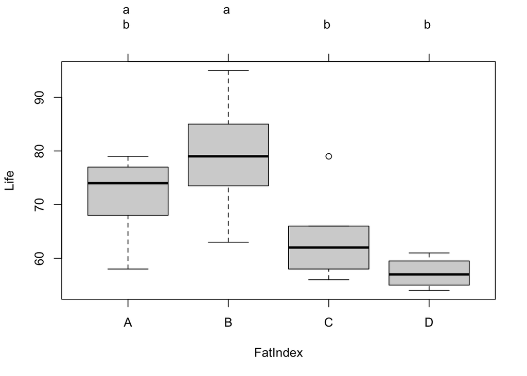

```r
plot(cld(result2)) # abcつきの箱ひげ図を描く
```

```r
# Holm補正による総当たりt検定も見ておく
pairwise.t.test(kadai2$Life,kadai2$FatIndex,p.adjust.method="holm")
```

```
##
##  Pairwise comparisons using t tests with pooled SD
##
## data:  kadai2$Life and kadai2$FatIndex
##
##   A      B      C
## B 0.3654 -      -
## C 0.4248 0.0339 -
## D 0.1033 0.0034 0.4248
##
## P value adjustment method: holm
```